# The {xdvir} Package

Paul Murrell

*The {xdvir} package provides functions for rendering LaTeX snippets in R plots.*

```r
library(xdvir)
```

# 1 Rendering LaTeX in R

The plot below, produced with R, features a LaTeX-quality mathematical equation in the top-left corner. Producing an equation like this requires three things:

1. A **markup** language that allows us to describe the equation.
2. A **typesetter** that can select fonts and individual glyphs from within those fonts and determine the exact placement of each individual glyph.
3. A **renderer** that can draw the glyphs from the fonts that the typesetter has selected in the locations that the typesetter has determined.

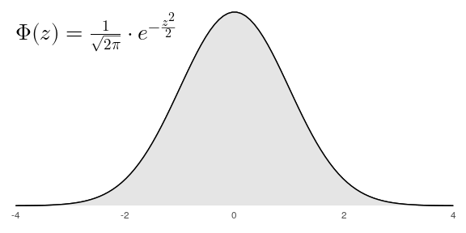

The {xdvir} package allows us to use LaTeX as the **markup** language, a TeX engine as the **typesetter**, and R as the **renderer**. This allows us to produce high-quality LaTeX typesetting within R plots, as in the image above.

The main function in {xdvir} is `grid.latex()`, which takes a LaTeX snippet and draws it on the current R graphics device. For example, the following code describes the mathematical equation, using LaTeX code, as a character value, then draws it by calling `grid.latex()` with the character value as the first argument.

Because LaTeX code tends to contain a large number of backslashes, the code below uses the `r"(...)"` syntax for raw character constants, so that we do not have to escape each backslash with a double backslash.

```r
tex <- r"(\huge $\Phi(z) = \frac{1}{\sqrt{2\pi}} \cdot e^{-\frac{z^2}{2}}$)"
```

```r
grid.latex(tex)
```

[output not shown]

# 2 LaTeX annotations in plots

The function `grid.latex()` only provides a low-level interface for drawing LaTeX snippets as part of {grid} output. However, there are ways to combine {grid} output with higher-level plotting packages.

For example, we can use {grid} within panel functions in the {lattice} package (Sarkar 2008). The following code draws a {lattice} plot and adds the mathematical equation in the top-left corner. This demonstrates that the `grid.latex()` function has arguments `x`, `y`, `hjust`, and `vjust` for positioning the LaTeX output.

```r
library(lattice)
```

```r
x <- seq(-4, 4, length.out=100)
df <- data.frame(x=x, y=dnorm(x))
```

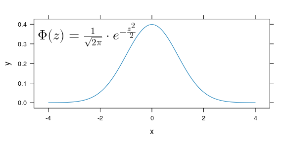

```r
xyplot(y ~ x, df, type="l",
       panel=function(...) {
           panel.xyplot(...)
           grid.latex(tex,
                      x=unit(2, "mm"),
                      y=unit(1, "npc") - unit(2, "mm"),
                      hjust="left", vjust="top")
       })
```

If we want to add {grid} output to a {graphics} plot, we can use the {gridGraphics} package (Murrell 2015; Murrell and Wen 2020). For example, the following code draws a {graphics} plot, uses `gridGraphics::grid.echo()` to convert it to {grid}, navigates to the {grid} viewport that represents the main plot region, and draws the mathematical equation in the top-left corner.

```r
library(gridGraphics)
```

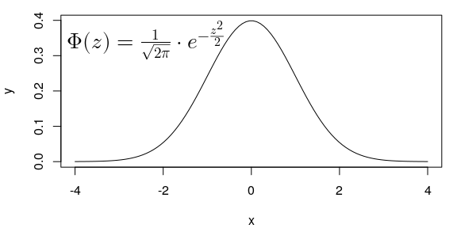

```r
plot(y ~ x, df, type="l")
grid.echo()
downViewport("graphics-plot-1")
grid.latex(tex,
           x=unit(2, "mm"),
           y=unit(1, "npc") - unit(2, "mm"),
           hjust="left", vjust="top")
```

We can add {grid} output to {ggplot2} plots (Wickham 2016) with the {gggrid} package (Murrell 2021, 2022). The following code uses the `latexGrob()` function to generate a “graphical object” for {ggplot2} to draw, rather than drawing the output immediately as `grid.latex()` does, and passes that to `gggrid::grid_panel()` so that the mathematical equation is added in the top-left corner of the plot.

```r
library(gggrid)
```

```r
gg <- ggplot(df) +
    geom_line(aes(x, y))
```

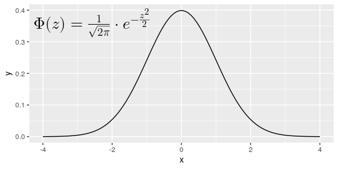

```r
gg +
    grid_panel(latexGrob(tex,
                         x=unit(2, "mm"),
                         y=unit(1, "npc") - unit(2, "mm"),
                         hjust="left", vjust="top"))
```

Another way to do this in {ggplot2} is with `ggplot2::annotation_custom()`, though precisely positioning the annotation may be less convenient.

# 3 LaTeX labels in {ggplot2}

The {xdvir} package also provides integration with labels in {ggplot2} plots. This allows, for example, the title of a plot to contain LaTeX code, as shown in the image below. For this to work, the relevant theme element must be set using `element_latex()`, as shown in the code below.

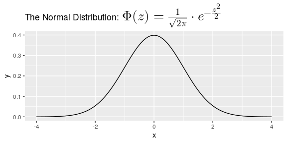

```r
gg +
    labs(title=paste("The Normal Distribution:", tex)) +
    theme(plot.title=element_latex())
```

Although the need is probably less, for completeness, there is also a `geom_latex()` for adding LaTeX-styled data symbols. For example, the following code adds LaTeX text labels to a dot plot.

```r
samples <- data.frame(x=rnorm(50), sample=rep(1:5, each=10))
means <- aggregate(samples$x, list(sample=samples$sample), mean)
means$label <- paste0("$\\bar x_", means$sample, "$")
```

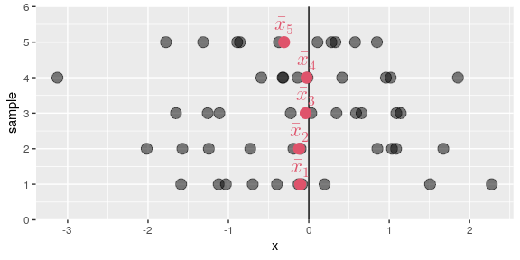

```r
ggplot(samples) +
    geom_vline(xintercept=0, linetype="solid", colour=1, linewidth=.5) +
    geom_point(aes(x, sample), size=4, alpha=.5) +
    geom_point(aes(x, sample), data=means, colour=2, size=4) +
    geom_latex(aes(x, sample, label=label), data=means,
               size=6, vjust=-.4, colour=2) +
    scale_y_continuous(expand=expansion(.25))
```

# 4 Related packages

The {xdvir} package provides similar functionality to the {gridtext} and {ggtext} packages (Wilke and Wiernik 2022b, 2022a) and the {marquee} package (Pedersen and Mitáš 2024). The main difference is the **markup** language that is supported. Where those packages are built on markdown, {xdvir} is built on LaTeX, with all of the joy and pain that that brings.

# 5 Trouble shooting

The {xdvir} package relies on the glyph rendering support that was added to the R graphics engine in R version 4.3.0 (Murrell, Pedersen, and Urbanek 2023). Furthermore, this support is only available on specific graphics devices: the core `pdf()`, Cairo-based devices, and `quartz()` devices, plus the devices provided by the {ragg} package (Pedersen and Shemanarev 2024).

# References

Murrell, Paul. 2015. “The gridGraphics Package.” *The R Journal* 7 (1): 151–62. https://doi.org/10.32614/RJ-2015-012.

———. 2021. “Accessing ’grid’ from ’ggplot2’.” 2021-01. Department of Statistics, The University of Auckland. https://doi.org/http://dx.doi.org/10.17608/k6.auckland.14703846.

———. 2022. *gggrid: Draw with ’grid’ in ’ggplot2’*. https://CRAN.R-project.org/package=gggrid.

Murrell, Paul, Thomas Lin Pedersen, and Simon Urbanek. 2023. “Rendering Typeset Glyphs in R Graphics.” 2023-01. Department of Statistics, The University of Auckland. https://doi.org/10.17608/k6.auckland.22774079.

Murrell, Paul, and Zhijian Wen. 2020. *gridGraphics: Redraw Base Graphics Using ’Grid’ Graphics*. https://CRAN.R-project.org/package=gridGraphics.

Pedersen, Thomas Lin, and Martin Mitáš. 2024. *marquee: Markdown Parser and Renderer for R Graphics*. https://CRAN.R-project.org/package=marquee.

Pedersen, Thomas Lin, and Maxim Shemanarev. 2024. *ragg: Graphic Devices Based on AGG*. https://CRAN.R-project.org/package=ragg.

Sarkar, Deepayan. 2008. *Lattice: Multivariate Data Visualization with R*. New York: Springer. http://lmdvr.r-forge.r-project.org.

Wickham, Hadley. 2016. *ggplot2: Elegant Graphics for Data Analysis*. Springer-Verlag New York. https://ggplot2.tidyverse.org.

Wilke, Claus O., and Brenton M. Wiernik. 2022a. *ggtext: Improved Text Rendering Support for ’ggplot2’*. https://CRAN.R-project.org/package=ggtext.

———. 2022b. *gridtext: Improved Text Rendering Support for ’Grid’ Graphics*. https://CRAN.R-project.org/package=gridtext.